# Lesson 3

### What to Do First?

- Opportunity to let the data surprise you
- Features of the data that might lead to unexpected results
- Understand the variables that are most central in the analysis

### Pseudo-Facebook User Data

Loading Facebook data

```r
getwd()
```

```
## [1] "H:/Dokumente/GitHub/2015_Data_Analyst_Project_4/lesson3"
```

```r
setwd("~/GitHub/2015_Data_Analyst_Project_4/lesson3")
pf <- read.csv('pseudo_facebook.tsv', sep = '\t')
```

### Histogram of Users’ Birthdays

Notes:

```r
# install.packages('ggplot2')
library(ggplot2)
names(pf)
```

```
##  [1] "userid"                "age"
##  [3] "dob_day"               "dob_year"
##  [5] "dob_month"             "gender"
##  [7] "tenure"                "friend_count"
##  [9] "friendships_initiated" "likes"
## [11] "likes_received"        "mobile_likes"
## [13] "mobile_likes_received" "www_likes"
## [15] "www_likes_received"
```

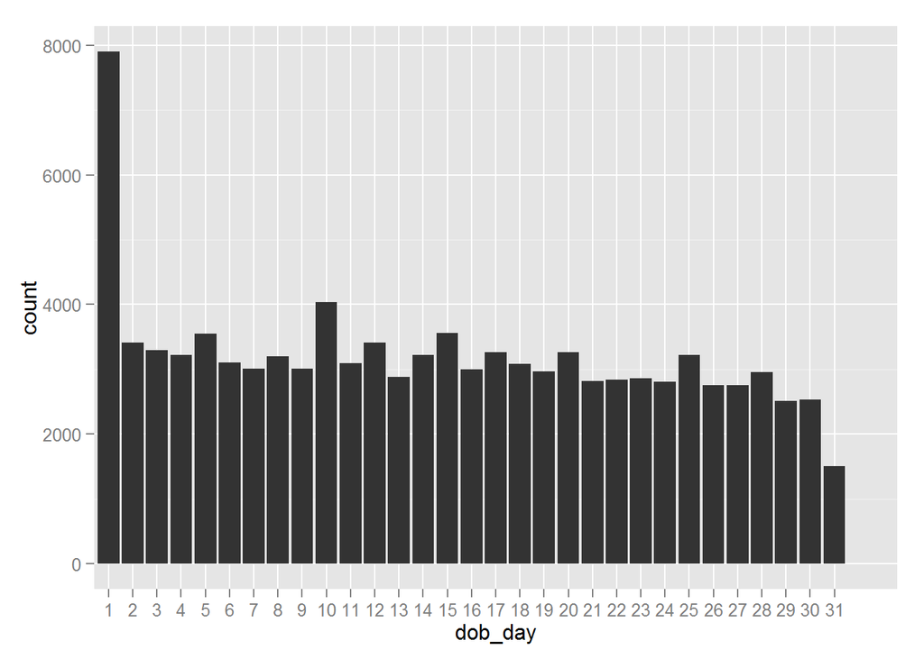

```r
qplot(x=dob_day, data=pf) +
  scale_x_discrete(breaks=1:31)
```

#### What are some things that you notice about this histogram?

Response: Large maximum at 1, almost equally distributed otherwise - probably many 1 also means unspecified day of month?

### Moira’s Investigation

Notes: Do peoples perception of the audience on facebook match reality? How many people are actually seeing facebook posts? [Bernstein, M. S., Bakshy, E., Burke, M., & Karrer, B. (2013). Quantifying the invisible audience in social networks. In Proceedings of the SIGCHI Conference on Human Factors in Computing Systems (CHI 2013), pp. 21-30.](http://hci.stanford.edu/publications/2013/invisibleaudience/invisibleaudience.pdf)

### Estimating Your Audience Size

Notes:

- Pointed people to a post
- Compared it to the number of people who have actually seen the post for about 1s

#### Think about a time when you posted a specific message or shared a photo on Facebook. What was it?

Response: new title picture with nature scene

#### How many of your friends do you think saw that post?

Response: 10%

#### Think about what percent of your friends on Facebook see any posts or comments that you make in a month. What percent do you think that is?

Response: 10%

### Perceived Audience Size

Notes: Many more people viewed the post than was guessed by the users. Actual size of audience was about 4 times as big.

### Faceting

Notes:

- Break histogram into twelve histograms with `facet_wrap(~variable, ncol=...)`
- Similar: `facet_grid(vertical_var~horizontal_var)`

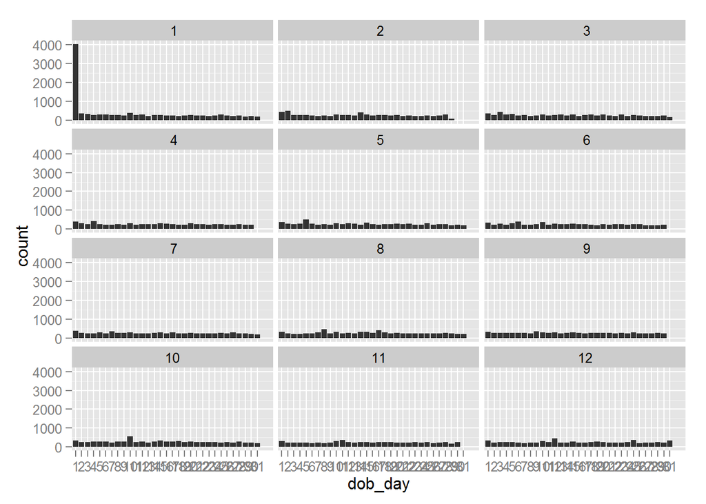

```r
qplot(x=dob_day, data=pf) +
  scale_x_discrete(breaks=1:31) +
  facet_wrap(~dob_month, ncol=3)
```

#### Let’s take another look at our plot. What stands out to you here?

Response: first of January occurs way more often

### Be Skeptical - Outliers and Anomalies

Notes:

- detecting and dealing with outliers is important
- many causes for outliers (accurate data about an extreme case, bad data / limitations of the data for a normal or extreme case)

### Moira’s Outlier

Notes: In Moira’s experiment, a few people guessed a number which was way too high (many millions of people), many people guessed a number way too low (no person at all)

#### Which case do you think applies to Moira’s outlier?

Response: - bad data about an extreme case - not: bad data about a non-extreme case - not: good data about an extreme case

### Friend Count

#### What code would you enter to create a histogram of friend counts?

```
## stat_bin: binwidth defaulted to range/30. Use 'binwidth = x' to adjust this.
```

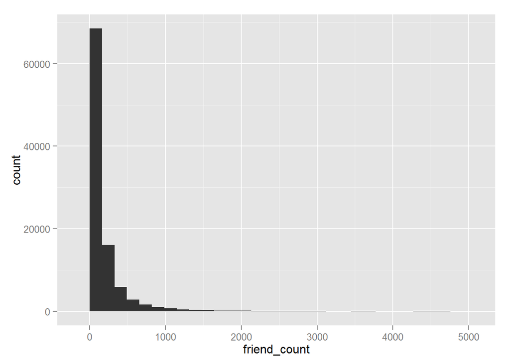

```r
qplot(x=friend_count, data=pf)
```

#### How is this plot similar to Moira’s first plot?

Response:

- long-tailed data: very few people with a huge number of friends (corresponding to very few people guessing a very high facebook post popularity)
- can be common for user-related data